# Linear Regression Assignment

Mendoza College of Business

10/28/2024

# Set Up

```r
load("nba_data.rda") # Load data
library(ggplot2)
```

The dataset we are using contains statistics on NBA games from 2010 to 2021, the features in the data are:

The statistics calculated are:

- fgm - Field goals made
- fga - Field goals attempted
- fg3m - 3 point shots made
- fg3a - 3 point shots attempted
- fg2m - 2 point shots made
- fg2a - 2 point shots attempted
- ftm - Free throws made
- fta - Free throws attempted
- oreb - Offensive rebounds
- dreb - Defensive rebounds
- treb - Total rebounds
- ast - Assists
- stl - Steals
- blk - Blocks
- tov - Turnovers
- pf - Personal fouls
- pts - Points scored
- pctfg - Field goal percentage
- pctfg2 - 2 point field goal percentage
- pctfg3 - 3 point field goal percentage
- pctft - Free throw percentage

These are calculated for the different aspects of the matchup denoted by the following adjustments to the variable names:

- _1_off - Offensive stats for team 1 in previous games
- _1_def - Defensive stats for team 1 in previous games (That is stats from team 1’s opponents)
- _2_off - Offensive stats for team 2 in previous games
- _2_def - Defensive stats for team 2 in previous games (That is stats from team 2’s opponents)

There is also an ELO rating function which can be used to provide a ranking of the teams:

https://medium.com/purple-theory/what-is-elo-rating-c4eb7a9061e0

The objective of our analysis is to determine the key factors involved in winning NBA games, so we will use point differential as our response variable.

```r
# Create response variable
nba_data$point_diff <- nba_data$team_1_points - nba_data$team_2_points
```

Before running the model we want to drop all of the unique identifiers for the games and the points used to calculate the differential:

```r
# Drop columns
nba_model <- nba_data[,c(8:91, 94:96)]
```

# Assignment

Please complete the following tasks and answer the following questions: * 1 - Create two visualizations which may reveal interesting relationships in the dataset. Describe what you see in the visualization. (2 Points)

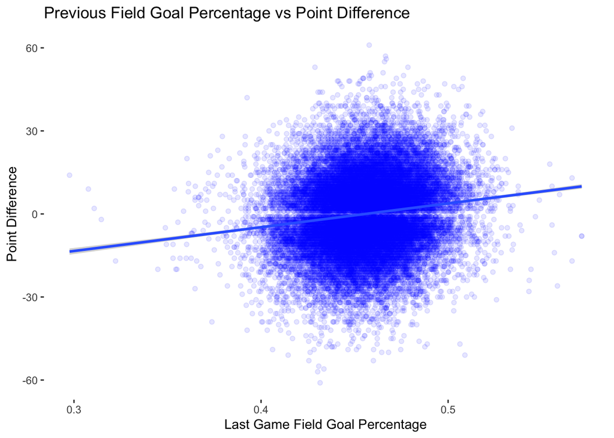

```r
g_1 <- ggplot(nba_model, # Set dataset
              aes(y = point_diff, # Set y-axis as insurance charges
                  x = pctfg_1_off)) + # Set x-axis as age.
  geom_point(color = "blue", alpha = 0.10) +
  geom_smooth(method = 'lm') +
  theme_bw() + # Set theme for plot
  theme(panel.grid.major = element_blank(), # Turn of the background grid
        panel.grid.minor = element_blank(),
        panel.border = element_blank(),
        panel.background = element_blank()) +
  labs(y = "Point Difference", # Set plot labels
       x = "Last Game Field Goal Percentage",
       title = "Previous Field Goal Percentage vs Point Difference")
g_1
```

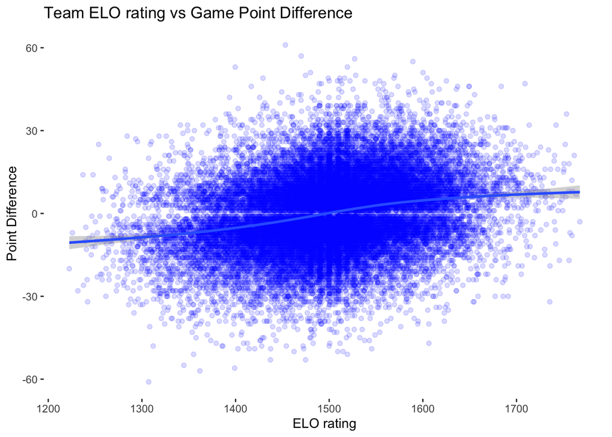

```r
g_2 <- ggplot(nba_model,
              aes(y = point_diff,
                  x = elo_1)) +
  geom_point(color = "blue", alpha = 0.15) +
  geom_smooth() +
  theme_bw() +
  theme(panel.grid.major = element_blank(),
        panel.grid.minor = element_blank(),
        panel.border = element_blank(),
        panel.background = element_blank()) +
  labs(y = "Point Difference",
       x = "ELO rating",
       title = "Team ELO rating vs Game Point Difference")
g_2
```

```r
lm_1 <- lm(point_diff ~.,
           data = nba_model)
summary(lm_1)
```

```
##
## Call:
## lm(formula = point_diff ~ ., data = nba_model)
##
## Residuals:
##     Min      1Q  Median      3Q     Max
## -57.249  -8.270  -0.001   8.290  57.911
##
## Coefficients: (16 not defined because of singularities)
##                Estimate Std. Error t value Pr(>|t|)
## (Intercept)  -1.683e+01  6.866e+01  -0.245 0.806317
## fgm_1_off     1.347e+00  8.183e-01   1.646 0.099747 .
## fga_1_off    -7.241e-01  3.838e-01  -1.887 0.059211 .
## fg3m_1_off   -5.723e-01  4.469e-01  -1.281 0.200335
## fg3a_1_off    4.471e-01  2.044e-01   2.187 0.028728 *
## fg2m_1_off           NA         NA      NA       NA
## fg2a_1_off           NA         NA      NA       NA
## ftm_1_off     3.031e-02  4.742e-01   0.064 0.949034
## fta_1_off    -1.374e-02  3.657e-01  -0.038 0.970027
## oreb_1_off    2.764e-01  8.899e-02   3.106 0.001901 **
## dreb_1_off    2.203e-01  6.430e-02   3.426 0.000614 ***
## treb_1_off           NA         NA      NA       NA
## ast_1_off     1.202e-01  4.380e-02   2.745 0.006058 **
## stl_1_off     3.867e-01  9.299e-02   4.158 3.22e-05 ***
## blk_1_off     1.854e-01  7.991e-02   2.320 0.020326 *
## tov_1_off    -3.675e-01  8.572e-02  -4.287 1.82e-05 ***
## pf_1_off      1.373e-01  6.597e-02   2.081 0.037457 *
## pts_1_off            NA         NA      NA       NA
## pctfg_1_off  -5.284e+01  6.495e+01  -0.814 0.415874
## pctfg2_1_off -2.064e+01  2.217e+01  -0.931 0.351977
## pctfg3_1_off  5.612e+00  7.233e+00   0.776 0.437773
## pctft_1_off   7.841e+00  1.130e+01   0.694 0.487711
## fgm_1_def    -2.781e+00  9.925e-01  -2.802 0.005079 **
## fga_1_def     1.301e+00  4.659e-01   2.793 0.005230 **
## fg3m_1_def    8.153e-01  6.714e-01   1.214 0.224605
## fg3a_1_def   -4.456e-01  3.046e-01  -1.463 0.143534
## fg2m_1_def           NA         NA      NA       NA
## fg2a_1_def           NA         NA      NA       NA
## ftm_1_def    -6.687e-01  6.736e-01  -0.993 0.320889
## fta_1_def     3.766e-01  5.150e-01   0.731 0.464626
```

[output cut: 49 more lines]

```
## pf_2_def     -1.319e-01  9.395e-02  -1.404 0.160252
## pts_2_def            NA         NA      NA       NA
## pctfg_2_def  -1.361e+02  7.679e+01  -1.773 0.076249 .
## pctfg2_2_def -3.649e+01  3.437e+01  -1.062 0.288339
## pctfg3_2_def -1.045e+01  1.070e+01  -0.977 0.328546
## pctft_2_def  -2.188e+01  1.611e+01  -1.359 0.174287
## elo_2        -2.418e-02  1.713e-03 -14.117  < 2e-16 ***
## elo_1         2.583e-02  1.649e-03  15.668  < 2e-16 ***
## ---
## Signif. codes:  0 '***' 0.001 '**' 0.01 '*' 0.05 '.' 0.1 ' ' 1
##
## Residual standard error: 12.77 on 27895 degrees of freedom
##   (430 observations deleted due to missingness)
## Multiple R-squared:  0.157,  Adjusted R-squared:  0.1549
## F-statistic: 74.21 on 70 and 27895 DF,  p-value: < 2.2e-16
```

- 3 - What features in the model were significant (At 0.1% level)? Do these variables have a positive or negative effect on a teams change of winning a game? (1 Point)

```r
summary_lm1 <- summary(lm_1)
lm1_coef <- summary_lm1$coefficients[summary_lm1$coefficients[,4] < 0.001,]
lm1_coef
```

```
##               Estimate  Std. Error    t value     Pr(>|t|)
## dreb_1_off  0.22028731 0.064300385   3.425910 6.136269e-04
## stl_1_off   0.38666313 0.092987100   4.158245 3.216599e-05
## tov_1_off  -0.36748528 0.085725385  -4.286773 1.818953e-05
## ast_1_def  -0.24289473 0.064528272  -3.764160 1.674524e-04
## ast_2_def   0.22032136 0.064933714   3.393020 6.922276e-04
## elo_2      -0.02417700 0.001712581 -14.117289 4.250751e-45
## elo_1       0.02583314 0.001648813  15.667716 4.320497e-55
```

The variables that have a significant *positive* effect on a teams chance of winning is `dreb_1_off`, `stl_1_off`, `ast_2_def`, and `elo_1`. The variables that have a significant *negative* effect on a teams chance of winning is `tov_1_off`, `ast_1_def`, and `elo_2`.

- 4 - Visualize two potential interaction terms and their relationship with the response variable. Are these interaction terms likely to have a significant relationship with the response variable? (2 Points)

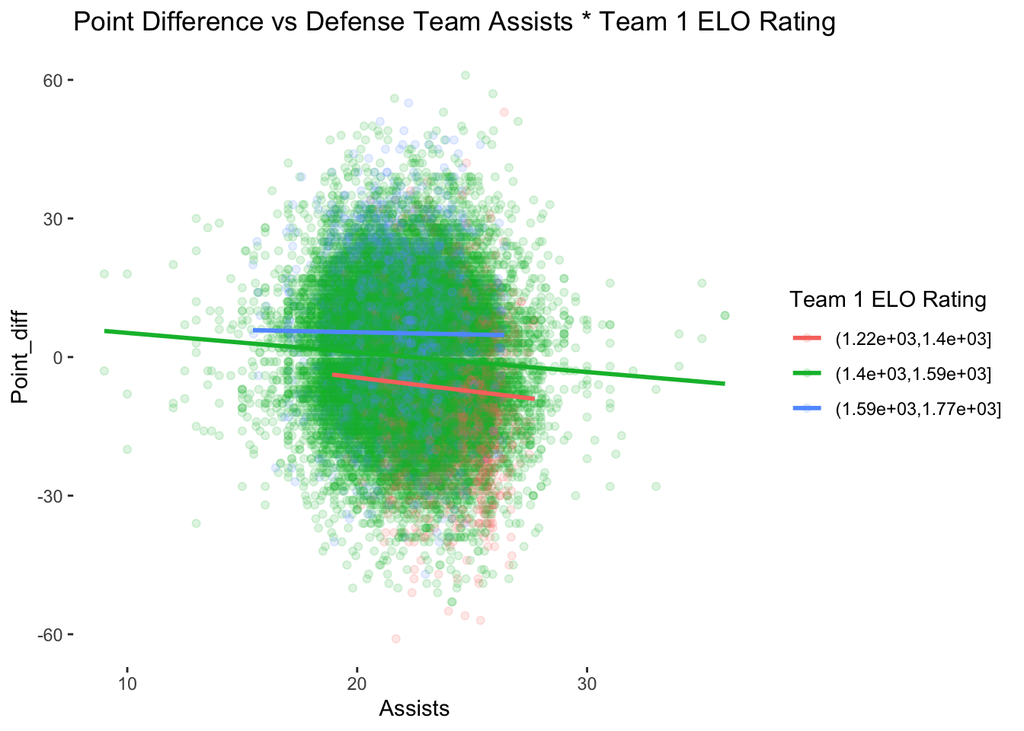

```r
g_3 <- ggplot(nba_model,
              aes(y = point_diff,
                  x = ast_1_def,
                  color = cut(elo_1, 3))) +
  geom_point(alpha = 0.15) +
  geom_smooth(method='lm', se = FALSE) +
  theme_bw() + # Set theme for plot
  theme(panel.grid.major = element_blank(),
        panel.grid.minor = element_blank(),
        panel.border = element_blank(),
        panel.background = element_blank()) +
  labs(y = "Point_diff",
       x = "Assists",
       title = "Point Difference vs Defense Team Assists * Team 1 ELO Rating",
       color = "Team 1 ELO Rating")
g_3
```

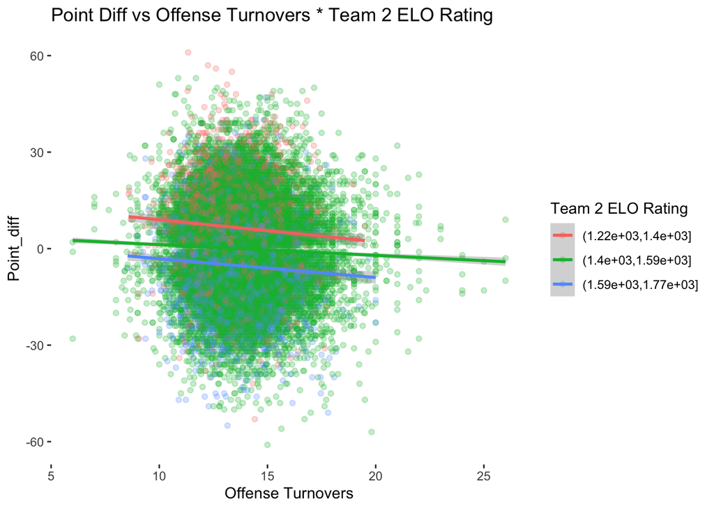

```r
g_4 <- ggplot(nba_model,
              aes(y = point_diff,
                  x = tov_1_off,
                  color = cut(elo_2, 3))) +
  geom_point(alpha = 0.25) +
  geom_smooth(method='lm') +
  theme_bw() +
  theme(panel.grid.major = element_blank(),
        panel.grid.minor = element_blank(),
        panel.border = element_blank(),
        panel.background = element_blank()) +
  labs(y = "Point_diff",
       x = "Offense Turnovers",
       title = "Point Diff vs Offense Turnovers * Team 2 ELO Rating",
       color = "Team 2 ELO Rating")
g_4
```

- 5 - Fit a linear regression model with the two interaction terms included. (1 Point)

```r
lm_2 <- lm(point_diff ~ . + elo_1 * tov_1_off + elo_2 * ast_1_def, data = nba_model)
summary(lm_2)
```

```
##
## Call:
## lm(formula = point_diff ~ . + elo_1 * tov_1_off + elo_2 * ast_1_def,
##     data = nba_model)
##
## Residuals:
##     Min      1Q  Median      3Q     Max
## -57.347  -8.265   0.008   8.295  57.637
##
## Coefficients: (16 not defined because of singularities)
##                   Estimate Std. Error t value Pr(>|t|)
## (Intercept)      2.334e+01  7.315e+01   0.319 0.749738
## fgm_1_off        1.468e+00  8.193e-01   1.792 0.073136 .
## fga_1_off       -7.818e-01  3.843e-01  -2.035 0.041907 *
## fg3m_1_off      -5.669e-01  4.469e-01  -1.269 0.204560
## fg3a_1_off       4.438e-01  2.044e-01   2.171 0.029915 *
## fg2m_1_off              NA         NA      NA       NA
## fg2a_1_off              NA         NA      NA       NA
## ftm_1_off        2.029e-02  4.742e-01   0.043 0.965864
## fta_1_off       -1.207e-02  3.657e-01  -0.033 0.973676
## oreb_1_off       2.823e-01  8.900e-02   3.171 0.001519 **
## dreb_1_off       2.179e-01  6.431e-02   3.388 0.000705 ***
## treb_1_off              NA         NA      NA       NA
## ast_1_off        1.139e-01  4.386e-02   2.597 0.009410 **
## stl_1_off        3.913e-01  9.299e-02   4.207 2.59e-05 ***
## blk_1_off        1.815e-01  7.991e-02   2.271 0.023173 *
## tov_1_off       -3.172e+00  1.006e+00  -3.152 0.001624 **
## pf_1_off         1.380e-01  6.596e-02   2.092 0.036415 *
## pts_1_off               NA         NA      NA       NA
## pctfg_1_off     -6.325e+01  6.504e+01  -0.972 0.330837
## pctfg2_1_off    -2.020e+01  2.217e+01  -0.911 0.362161
## pctfg3_1_off     5.557e+00  7.232e+00   0.768 0.442236
## pctft_1_off      8.005e+00  1.130e+01   0.709 0.478603
## fgm_1_def       -2.541e+00  9.961e-01  -2.551 0.010755 *
## fga_1_def        1.190e+00  4.676e-01   2.544 0.010955 *
## fg3m_1_def       7.754e-01  6.715e-01   1.155 0.248238
## fg3a_1_def      -4.313e-01  3.047e-01  -1.416 0.156926
## fg2m_1_def              NA         NA      NA       NA
## fg2a_1_def              NA         NA      NA       NA
## ftm_1_def       -6.094e-01  6.739e-01  -0.904 0.365853
```

[output cut: 52 more lines]

```
## pctfg_2_def     -1.283e+02  7.736e+01  -1.659 0.097153 .
## pctfg2_2_def    -3.996e+01  3.467e+01  -1.153 0.248981
## pctfg3_2_def    -9.945e+00  1.072e+01  -0.928 0.353511
## pctft_2_def     -2.210e+01  1.611e+01  -1.372 0.170076
## elo_2           -1.601e-02  1.205e-02  -1.329 0.183908
## elo_1            3.676e-04  9.253e-03   0.040 0.968313
## tov_1_off:elo_1  1.877e-03  6.710e-04   2.797 0.005162 **
## ast_1_def:elo_2 -3.645e-04  5.333e-04  -0.683 0.494355
## ---
## Signif. codes:  0 '***' 0.001 '**' 0.01 '*' 0.05 '.' 0.1 ' ' 1
##
## Residual standard error: 12.77 on 27893 degrees of freedom
##   (430 observations deleted due to missingness)
## Multiple R-squared:  0.1572, Adjusted R-squared:  0.1551
## F-statistic: 72.28 on 72 and 27893 DF,  p-value: < 2.2e-16
```

```r
summary_lm2 <- summary(lm_2)
lm2_coef <- summary_lm2$coefficients[summary_lm2$coefficients[,4] < 0.001,]
lm2_coef
```

```
##             Estimate Std. Error  t value     Pr(>|t|)
## dreb_1_off 0.2178581 0.06430533 3.387870 7.053500e-04
## stl_1_off  0.3912531 0.09299319 4.207331 2.592119e-05
## ast_2_def  0.2212773 0.06499939 3.404298 6.642775e-04
```

```r
lm1_coef
```

```
##               Estimate  Std. Error    t value     Pr(>|t|)
## dreb_1_off  0.22028731 0.064300385   3.425910 6.136269e-04
## stl_1_off   0.38666313 0.092987100   4.158245 3.216599e-05
## tov_1_off  -0.36748528 0.085725385  -4.286773 1.818953e-05
## ast_1_def  -0.24289473 0.064528272  -3.764160 1.674524e-04
## ast_2_def   0.22032136 0.064933714   3.393020 6.922276e-04
## elo_2      -0.02417700 0.001712581 -14.117289 4.250751e-45
## elo_1       0.02583314 0.001648813  15.667716 4.320497e-55
```

2 Points for code quality and analysis decisions.